# Randomization Tests

Saint Michael's College  
July 24, 2017

### Source of Data

All data used in these slides come from the textbook:

Lock, R. H., Lock, R. H., Morgan, K. L., Lock, E. F., & Lock, D. F. (2013). Statistics: Unlocking the power of data. Hoboken, NJ: Wiley.

These data are publicly available.

### Sleep or Caffeine

In a 2008 study by Mednick, Cai, Kanady and Drummond, 24 adults were given a list of 24 words to memorize. During a 90 minute break, 12 participants were given a nap, while the other 12 were given a caffeine pill and no nap. After the break, the number of words that each participant was able to recall was recorded.

| Treatment |  |  |  |  |  |  |  |  |  |  |  |  | Mean |
| --- | --- | --- | --- | --- | --- | --- | --- | --- | --- | --- | --- | --- | --- |
| Sleep | 14 | 18 | 11 | 13 | 18 | 17 | 21 | 9 | 16 | 17 | 14 | 15 | 15.25 |
| Caffeine | 12 | 12 | 14 | 13 | 6 | 18 | 14 | 16 | 10 | 7 | 15 | 10 | 12.25 |

Does this study provide evidence that either sleep or caffeine has a stronger effect on memory than the other?

### Randomness in Data

Two samples are almost certain to differ even if they came from the same distribution. For example, the following two random samples were both generated from the same distribution.

```
[1]  94 108  85 102  56
```

```
[1] 116  94  62  87  73
```

Central Question: Would it be unusual to get a difference in sample means as large as we did if there was really no difference between treatment effects?

### Permutation Testing

- Pick a statistic from our data to represent the quantity we are interested in.
- Simulate the distribution of our statistic, assuming there is really no difference between treatments.
- Is our sample consistent with the belief that there are no differences between treatment groups?

### Simulating the Permutation Distribution

1. Tear off each number from the index cards so you have 24 different numbered pieces.
2. Shuffle the cards and randomly assign them to groups of 12.
3. Calculate the difference in group means.
4. Repeat 5 times.

What does the distribution of “shuffled” group mean differences represent?

Is a group mean difference of 3 or more unusual?

### Permutation Distribution Applet

We can quickly simulate the permutation distribution for a statistic using a Shiny app https://istats.shinyapps.io/PermDist_2samples/.

What can we conclude about the relationship between sleep and caffeine on memory?

### Light at Night for Mice

In nature, mice typically eat and are most active when it is dark. In a study by Fronken, 18 mice were randomly assigned to two groups. Both groups were kept in light during the day. One group was exposed to dim light at night while the other was kept in the dark. The mice exposed to light at night ate most of their food during the day, while the other mice typically ate when it was dark. The change is body mass was recorded after 3 weeks.

| Treatment |  |  |  |  |  |  |  |  |  |  |
| --- | --- | --- | --- | --- | --- | --- | --- | --- | --- | --- |
| Light | 1.71 | 4.67 | 4.99 | 5.33 | 5.43 | 6.94 | 7.15 | 9.17 | 10.26 | 11.67 |
| Dark | 2.27 | 2.53 | 2.83 | 4 | 4.21 | 4.6 | 5.95 | 6.52 |  |  |

How strong is the evidence that exposure to light at night contributes to weight gain in mice?

### Rat Empathy

| Gender |  |  |  |  |  |  |  |  |  |  |  |  |  |  |  |  |  |
| --- | --- | --- | --- | --- | --- | --- | --- | --- | --- | --- | --- | --- | --- | --- | --- | --- | --- |
| Male | 1 | 1 | 1 | 0 | 0 | 1 | 0 | 1 | 0 | 1 | 1 | 1 | 1 | 1 | 1 | 1 | 1 |
|  | 0 | 1 | 0 | 1 | 0 | 1 | 1 |  |  |  |  |  |  |  |  |  |  |
| Female | 1 | 1 | 1 | 1 | 1 | 1 |  |  |  |  |  |  |  |  |  |  |  |

1=freed trapped rat, 0=did not free trapped rat

Does this study provide evidence that female rats are more compassionate than male rats?

### Discussion

1. What other information might be helpful to know before deciding whether exposure to light at night contributes to weight gain in mice?
2. Is it reasonable to generalize the results of the light-at-night study to all mice of the same species? All mice? Does this suggest that humans who sleep with the light on are likely to gain weight?
3. Is it correct to conclude that female rats are no more likely to free a trapped companion than male rats?

### Simulation Activity

The following four slides contain simulated data. Is there evidence to conclude the two groups on a slide were simulated using a different mean setting?

Work in teams to determine whether you are willing to conclude that the data were obtained using different settings.

### Simulation 1

Group A:

[output not shown]

Group B:

[output not shown]

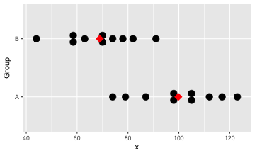

### Simulation 2

Group A:

```
   [1]  40 153  92 116 131 149 170  20  42 118
```

Group B:

```
   [1] 143  47 103  62 110  99  96 119 104  81
```

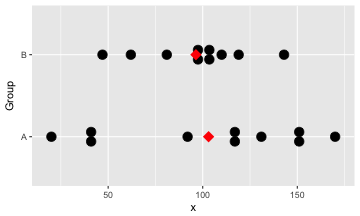

### Simulation 3

Group A:

```
   [1] 62 56 58 58 61 57 60 60 58 61
```

Group B:

```
   [1] 65 66 63 69 67 69 60 66 64 63
```

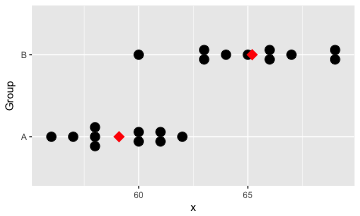

### Simulation 4

Group A:

```
  [1] 52 45 67 52 83
```

Group B:

```
  [1] 47 47 44 63 69
```

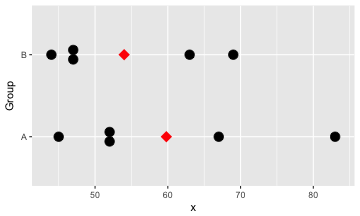

### Discussion

- What considerations helped you determine whether there was evidence that data were generated using the same settings?

### Association between two Quantitative Variables

The scatterplot shows the relationship between the acidity (pH) of Florida lakes and the average mercury level (ppm) of fish from each lake.

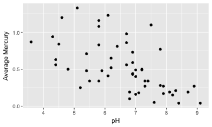

How can we test whether these data provide evidence of a relationship between acidity and mercury level in fish?

### Discussion

1. What assumption(s) are permutation tests based on?
2. What assumptions that you might have seen in other contexts did we not make here?

### Final Thoughts

“Actually, the statistician does not carry out this very simple and very tedious process, but his conclusions have no justification beyond the fact that they agree with those which could have been arrived at by this elementary method.”

-Ronald A. Fisher (1936)